# Project

NAVEEN RAJU SREERAMA RAJU GOVINDA RAJU , RAGHUNATH BABU , SHRIYA PRASANNA

2022-11-25

```r
setwd("C:/Users/Naveen/Desktop/Applied Statistics/project/real estate/")
data1 <- read.csv("./data.csv", sep=",")
# data1<-subset(data1,select=-c(state,communityname,fold))

head(data1)
```

|  | CRIM | ZN | INDUS | CHAS | NOX | RM | AGE | DIS | RAD | TAX | PTRATIO | B | LSTAT | MEDV |
| --- | --- | --- | --- | --- | --- | --- | --- | --- | --- | --- | --- | --- | --- | --- |
| 1 | 0.00632 | 18 | 2.31 | 0 | 0.538 | 6.575 | 65.2 | 4.0900 | 1 | 296 | 15.3 | 396.90 | 4.98 | 24.0 |
| 2 | 0.02731 | 0 | 7.07 | 0 | 0.469 | 6.421 | 78.9 | 4.9671 | 2 | 242 | 17.8 | 396.90 | 9.14 | 21.6 |
| 3 | 0.02729 | 0 | 7.07 | 0 | 0.469 | 7.185 | 61.1 | 4.9671 | 2 | 242 | 17.8 | 392.83 | 4.03 | 34.7 |
| 4 | 0.03237 | 0 | 2.18 | 0 | 0.458 | 6.998 | 45.8 | 6.0622 | 3 | 222 | 18.7 | 394.63 | 2.94 | 33.4 |
| 5 | 0.06905 | 0 | 2.18 | 0 | 0.458 | 7.147 | 54.2 | 6.0622 | 3 | 222 | 18.7 | 396.90 | 5.33 | 36.2 |
| 6 | 0.02985 | 0 | 2.18 | 0 | 0.458 | 6.430 | 58.7 | 6.0622 | 3 | 222 | 18.7 | 394.12 | 5.21 | 28.7 |

```r
ncol(data1)
```

```
[1] 14
```

```r
# summary(trans)
```

### 4.1-1

To find which column has NA

```r
list_na <- colnames(data1)[ apply(data1, 2, anyNA) ]
list_na
```

```
[1] "RM"
```

```r
data1[!complete.cases(data1),]
```

|  | CRIM | ZN | INDUS | CHAS | NOX | RM | AGE | DIS | RAD | TAX | PTRATIO | B | LSTAT | MEDV |
| --- | --- | --- | --- | --- | --- | --- | --- | --- | --- | --- | --- | --- | --- | --- |
| 11 | 0.22489 | 12.5 | 7.87 | 0 | 0.524 | NA | 94.3 | 6.3467 | 5 | 311 | 15.2 | 392.52 | 20.45 | 15.0 |
| 36 | 0.06417 | 0.0 | 5.96 | 0 | 0.499 | NA | 68.2 | 3.3603 | 5 | 279 | 19.2 | 396.90 | 9.68 | 18.9 |
| 64 | 0.12650 | 25.0 | 5.13 | 0 | 0.453 | NA | 43.4 | 7.9809 | 8 | 284 | 19.7 | 395.58 | 9.50 | 25.0 |
| 97 | 0.11504 | 0.0 | 2.89 | 0 | 0.445 | NA | 69.6 | 3.4952 | 2 | 276 | 18.0 | 391.83 | 11.34 | 21.4 |
| 136 | 0.55778 | 0.0 | 21.89 | 0 | 0.624 | NA | 98.2 | 2.1107 | 4 | 437 | 21.2 | 394.67 | 16.96 | 18.1 |

Find the median of values of that column that has NA

```r
median<-median(data1$RM, na.rm=TRUE)
print(median)
```

```
[1] 6.208
```

Replace NA in “RM” column with median values and recheck again if NA is there in that column

```r
data1[is.na(data1$RM),"RM"]<-median
print(data1)
```

| CRIM | ZN | INDUS | CHAS | NOX | RM | AGE | DIS | RAD | TAX | PTRATIO | B | LSTAT | MEDV |
| --- | --- | --- | --- | --- | --- | --- | --- | --- | --- | --- | --- | --- | --- |
| 0.00632 | 18.0 | 2.31 | 0 | 0.5380 | 6.575 | 65.2 | 4.0900 | 1 | 296 | 15.3 | 396.90 | 4.98 | 24.0 |
| 0.02731 | 0.0 | 7.07 | 0 | 0.4690 | 6.421 | 78.9 | 4.9671 | 2 | 242 | 17.8 | 396.90 | 9.14 | 21.6 |
| 0.02729 | 0.0 | 7.07 | 0 | 0.4690 | 7.185 | 61.1 | 4.9671 | 2 | 242 | 17.8 | 392.83 | 4.03 | 34.7 |
| 0.03237 | 0.0 | 2.18 | 0 | 0.4580 | 6.998 | 45.8 | 6.0622 | 3 | 222 | 18.7 | 394.63 | 2.94 | 33.4 |
| 0.06905 | 0.0 | 2.18 | 0 | 0.4580 | 7.147 | 54.2 | 6.0622 | 3 | 222 | 18.7 | 396.90 | 5.33 | 36.2 |
| 0.02985 | 0.0 | 2.18 | 0 | 0.4580 | 6.430 | 58.7 | 6.0622 | 3 | 222 | 18.7 | 394.12 | 5.21 | 28.7 |
| 0.08829 | 12.5 | 7.87 | 0 | 0.5240 | 6.012 | 66.6 | 5.5605 | 5 | 311 | 15.2 | 395.60 | 12.43 | 22.9 |
| 0.14455 | 12.5 | 7.87 | 0 | 0.5240 | 6.172 | 96.1 | 5.9505 | 5 | 311 | 15.2 | 396.90 | 19.15 | 27.1 |
| 0.21124 | 12.5 | 7.87 | 0 | 0.5240 | 5.631 | 100.0 | 6.0821 | 5 | 311 | 15.2 | 386.63 | 29.93 | 16.5 |
| 0.17004 | 12.5 | 7.87 | 0 | 0.5240 | 6.004 | 85.9 | 6.5921 | 5 | 311 | 15.2 | 386.71 | 17.10 | 18.9 |

[output cut: 496 more lines]

```r
list_na <- colnames(data1)[ apply(data1, 2, anyNA) ]
list_na
```

```
character(0)
```

Saving NA replaced data frame

```r
data_rm<-data1
write.csv(data1,"./new_data1.csv", row.names = FALSE)
```

Analyzing summary of the dataset

```r
summary(data1)
```

```
      CRIM                ZN             INDUS            CHAS              NOX
 Min.   : 0.00632   Min.   :  0.00   Min.   : 0.46   Min.   :0.00000   Min.   :0.3850
 1st Qu.: 0.08205   1st Qu.:  0.00   1st Qu.: 5.19   1st Qu.:0.00000   1st Qu.:0.4490
 Median : 0.25651   Median :  0.00   Median : 9.69   Median :0.00000   Median :0.5380
 Mean   : 3.61352   Mean   : 11.36   Mean   :11.14   Mean   :0.06917   Mean   :0.5547
 3rd Qu.: 3.67708   3rd Qu.: 12.50   3rd Qu.:18.10   3rd Qu.:0.00000   3rd Qu.:0.6240
 Max.   :88.97620   Max.   :100.00   Max.   :27.74   Max.   :1.00000   Max.   :0.8710
       RM             AGE              DIS              RAD              TAX
 Min.   :3.561   Min.   :  2.90   Min.   : 1.130   Min.   : 1.000   Min.   :187.0
 1st Qu.:5.886   1st Qu.: 45.02   1st Qu.: 2.100   1st Qu.: 4.000   1st Qu.:279.0
 Median :6.208   Median : 77.50   Median : 3.207   Median : 5.000   Median :330.0
 Mean   :6.284   Mean   : 68.57   Mean   : 3.795   Mean   : 9.549   Mean   :408.2
 3rd Qu.:6.619   3rd Qu.: 94.08   3rd Qu.: 5.188   3rd Qu.:24.000   3rd Qu.:666.0
 Max.   :8.780   Max.   :100.00   Max.   :12.127   Max.   :24.000   Max.   :711.0
    PTRATIO            B              LSTAT            MEDV
 Min.   :12.60   Min.   :  0.32   Min.   : 1.73   Min.   : 5.00
 1st Qu.:17.40   1st Qu.:375.38   1st Qu.: 6.95   1st Qu.:17.02
 Median :19.05   Median :391.44   Median :11.36   Median :21.20
 Mean   :18.46   Mean   :356.67   Mean   :12.65   Mean   :22.53
 3rd Qu.:20.20   3rd Qu.:396.23   3rd Qu.:16.95   3rd Qu.:25.00
 Max.   :22.00   Max.   :396.90   Max.   :37.97   Max.   :50.00
```

### 4.1-2

Analyzing histogram of each column of the data set

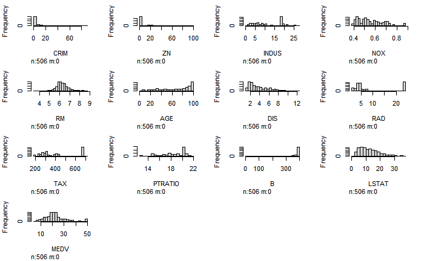

```r
# install.packages("Hmisc")
library(Hmisc)
hist.data.frame(data1)
```

### 4.2-1

Fitting the linear regression with response variable “MEDV” and all other columns as predictor variables

```r
model1=lm(formula = MEDV ~ ., data = data1)
summary(model1)
```

```
Call:
lm(formula = MEDV ~ ., data = data1)

Residuals:
     Min       1Q   Median       3Q      Max
-15.5668  -2.7318  -0.5093   1.7751  26.1794

Coefficients:
              Estimate Std. Error t value Pr(>|t|)
(Intercept)  36.469734   5.124390   7.117 3.93e-12 ***
CRIM         -0.108090   0.032900  -3.285 0.001091 **
ZN            0.046393   0.013745   3.375 0.000795 ***
INDUS         0.021983   0.061579   0.357 0.721258
CHAS          2.684377   0.862507   3.112 0.001964 **
NOX         -17.723130   3.824460  -4.634 4.60e-06 ***
RM            3.797127   0.419613   9.049  < 2e-16 ***
AGE           0.001053   0.013219   0.080 0.936543
DIS          -1.463262   0.199876  -7.321 1.01e-12 ***
RAD           0.307699   0.066399   4.634 4.60e-06 ***
TAX          -0.012428   0.003764  -3.302 0.001030 **
PTRATIO      -0.953338   0.130976  -7.279 1.34e-12 ***
B             0.009322   0.002689   3.467 0.000573 ***
LSTAT        -0.525345   0.050827 -10.336  < 2e-16 ***
---
Signif. codes:  0 ‘***’ 0.001 ‘**’ 0.01 ‘*’ 0.05 ‘.’ 0.1 ‘ ’ 1

Residual standard error: 4.75 on 492 degrees of freedom
Multiple R-squared:  0.7401,    Adjusted R-squared:  0.7332
F-statistic: 107.8 on 13 and 492 DF,  p-value: < 2.2e-16
```

```r
anova(model1)
```

```
Analysis of Variance Table

Response: MEDV
           Df  Sum Sq Mean Sq  F value    Pr(>F)
CRIM        1  6440.8  6440.8 285.4246 < 2.2e-16 ***
ZN          1  3554.3  3554.3 157.5111 < 2.2e-16 ***
INDUS       1  2551.2  2551.2 113.0586 < 2.2e-16 ***
CHAS        1  1529.8  1529.8  67.7955 1.645e-15 ***
NOX         1    76.2    76.2   3.3789 0.0666376 .
RM          1 10958.5 10958.5 485.6270 < 2.2e-16 ***
AGE         1    89.9    89.9   3.9820 0.0465396 *
DIS         1  1728.0  1728.0  76.5763 < 2.2e-16 ***
RAD         1    33.9    33.9   1.5018 0.2209830
TAX         1   336.4   336.4  14.9089 0.0001279 ***
PTRATIO     1  1308.4  1308.4  57.9810 1.365e-13 ***
B           1   595.8   595.8  26.4017 4.005e-07 ***
LSTAT       1  2410.8  2410.8 106.8337 < 2.2e-16 ***
Residuals 492 11102.3    22.6
---
Signif. codes:  0 ‘***’ 0.001 ‘**’ 0.01 ‘*’ 0.05 ‘.’ 0.1 ‘ ’ 1
```

### 4.2-2-a

Analyzing correlation of features

```r
round(cor(data1),3)
```

```
          CRIM     ZN  INDUS   CHAS    NOX     RM    AGE    DIS    RAD    TAX PTRATIO      B
CRIM     1.000 -0.200  0.407 -0.056  0.421 -0.219  0.353 -0.380  0.626  0.583   0.290 -0.385
ZN      -0.200  1.000 -0.534 -0.043 -0.517  0.311 -0.570  0.664 -0.312 -0.315  -0.392  0.176
INDUS    0.407 -0.534  1.000  0.063  0.764 -0.392  0.645 -0.708  0.595  0.721   0.383 -0.357
CHAS    -0.056 -0.043  0.063  1.000  0.091  0.092  0.087 -0.099 -0.007 -0.036  -0.122  0.049
NOX      0.421 -0.517  0.764  0.091  1.000 -0.302  0.731 -0.769  0.611  0.668   0.189 -0.380
RM      -0.219  0.311 -0.392  0.092 -0.302  1.000 -0.240  0.202 -0.210 -0.292  -0.356  0.128
AGE      0.353 -0.570  0.645  0.087  0.731 -0.240  1.000 -0.748  0.456  0.506   0.262 -0.274
DIS     -0.380  0.664 -0.708 -0.099 -0.769  0.202 -0.748  1.000 -0.495 -0.534  -0.232  0.292
RAD      0.626 -0.312  0.595 -0.007  0.611 -0.210  0.456 -0.495  1.000  0.910   0.465 -0.444
TAX      0.583 -0.315  0.721 -0.036  0.668 -0.292  0.506 -0.534  0.910  1.000   0.461 -0.442
PTRATIO  0.290 -0.392  0.383 -0.122  0.189 -0.356  0.262 -0.232  0.465  0.461   1.000 -0.177
B       -0.385  0.176 -0.357  0.049 -0.380  0.128 -0.274  0.292 -0.444 -0.442  -0.177  1.000
LSTAT    0.456 -0.413  0.604 -0.054  0.591 -0.615  0.602 -0.497  0.489  0.544   0.374 -0.366
MEDV    -0.388  0.360 -0.484  0.175 -0.427  0.696 -0.377  0.250 -0.382 -0.469  -0.508  0.333
         LSTAT   MEDV
CRIM     0.456 -0.388
ZN      -0.413  0.360
INDUS    0.604 -0.484
CHAS    -0.054  0.175
NOX      0.591 -0.427
RM      -0.615  0.696
AGE      0.602 -0.377
DIS     -0.497  0.250
RAD      0.489 -0.382
TAX      0.544 -0.469
PTRATIO  0.374 -0.508
B       -0.366  0.333
LSTAT    1.000 -0.738
MEDV    -0.738  1.000
```

### 4.2-2-b

Eliminating variable with high multi-collinearity used VIF VIF score

```r
library(car)
car::vif(model1)
```

```
    CRIM       ZN    INDUS     CHAS      NOX       RM      AGE      DIS      RAD      TAX
1.792182 2.299627 3.993939 1.074029 4.395254 1.942544 3.098649 3.964268 7.480394 9.005566
 PTRATIO        B    LSTAT
1.799379 1.348833 2.948156
```

The VIF score of Tax is very high, thus we are removing the predictor variable TAX from the regression Removing “tax” predictor variable.Doing so,Residual standard error marginally increased to 4.798 from 4.75. But,Adjusted R-squared marginally decreased to 0.7279 from 0.7332.So we can remove it.

```r
data1 <- subset(data1, select=-c(TAX))
model1=lm(formula = MEDV ~ ., data = data1)
summary(model1)
```

```
Call:
lm(formula = MEDV ~ ., data = data1)

Residuals:
     Min       1Q   Median       3Q      Max
-16.1160  -2.9064  -0.5767   1.7059  26.2865

Coefficients:
              Estimate Std. Error t value Pr(>|t|)
(Intercept)  3.465e+01  5.145e+00   6.733 4.63e-11 ***
CRIM        -1.068e-01  3.323e-02  -3.215 0.001392 **
ZN           3.628e-02  1.353e-02   2.681 0.007594 **
INDUS       -6.705e-02  5.591e-02  -1.199 0.231061
CHAS         3.030e+00  8.647e-01   3.504 0.000501 ***
NOX         -1.867e+01  3.852e+00  -4.846 1.69e-06 ***
RM           3.897e+00  4.227e-01   9.219  < 2e-16 ***
AGE         -2.291e-04  1.335e-02  -0.017 0.986313
DIS         -1.476e+00  2.018e-01  -7.313 1.07e-12 ***
RAD          1.350e-01  4.130e-02   3.268 0.001159 **
PTRATIO     -9.861e-01  1.319e-01  -7.476 3.53e-13 ***
B            9.558e-03  2.715e-03   3.520 0.000471 ***
LSTAT       -5.230e-01  5.133e-02 -10.188  < 2e-16 ***
---
Signif. codes:  0 ‘***’ 0.001 ‘**’ 0.01 ‘*’ 0.05 ‘.’ 0.1 ‘ ’ 1

Residual standard error: 4.798 on 493 degrees of freedom
Multiple R-squared:  0.7343,    Adjusted R-squared:  0.7279
F-statistic: 113.6 on 12 and 493 DF,  p-value: < 2.2e-16
```

```r
anova(model1)
```

```
Analysis of Variance Table

Response: MEDV
           Df  Sum Sq Mean Sq  F value    Pr(>F)
CRIM        1  6440.8  6440.8 279.8045 < 2.2e-16 ***
ZN          1  3554.3  3554.3 154.4097 < 2.2e-16 ***
INDUS       1  2551.2  2551.2 110.8324 < 2.2e-16 ***
CHAS        1  1529.8  1529.8  66.4606 2.973e-15 ***
NOX         1    76.2    76.2   3.3124   0.06937 .
RM          1 10958.5 10958.5 476.0649 < 2.2e-16 ***
AGE         1    89.9    89.9   3.9036   0.04874 *
DIS         1  1728.0  1728.0  75.0685 < 2.2e-16 ***
RAD         1    33.9    33.9   1.4722   0.22558
PTRATIO     1  1401.7  1401.7  60.8942 3.630e-14 ***
B           1   614.3   614.3  26.6849 3.483e-07 ***
LSTAT       1  2389.4  2389.4 103.8000 < 2.2e-16 ***
Residuals 493 11348.3    23.0
---
Signif. codes:  0 ‘***’ 0.001 ‘**’ 0.01 ‘*’ 0.05 ‘.’ 0.1 ‘ ’ 1
```

### 4.2-3

scatter plot for plots individually

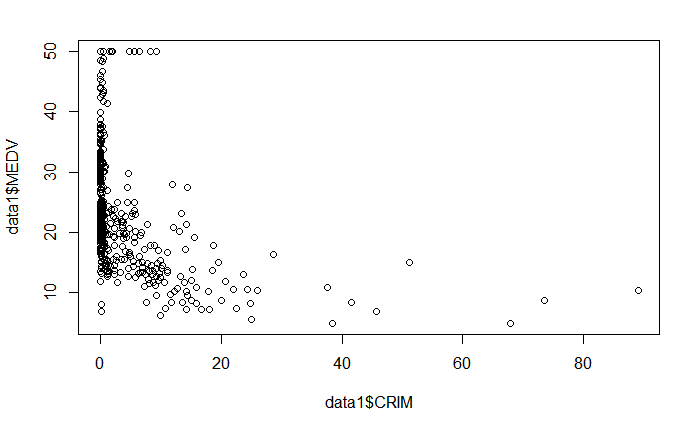

```r
plot(data1$CRIM,data1$MEDV)
```

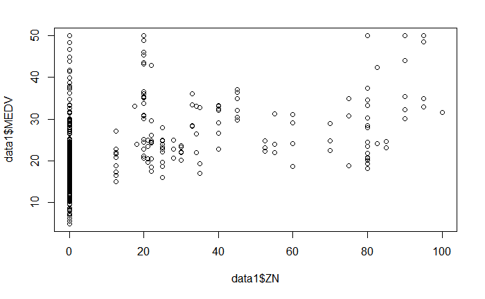

```r
plot(data1$ZN,data1$MEDV)
```

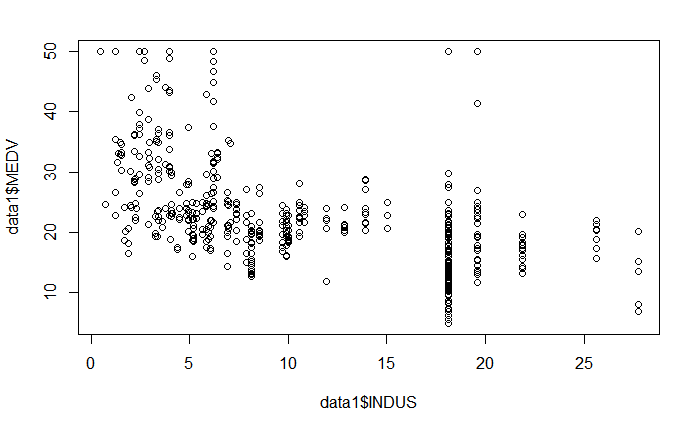

```r
plot(data1$INDUS,data1$MEDV)
```

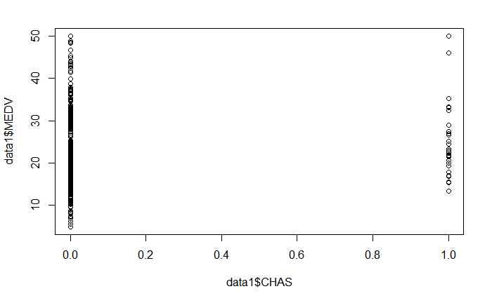

```r
plot(data1$CHAS,data1$MEDV)
```

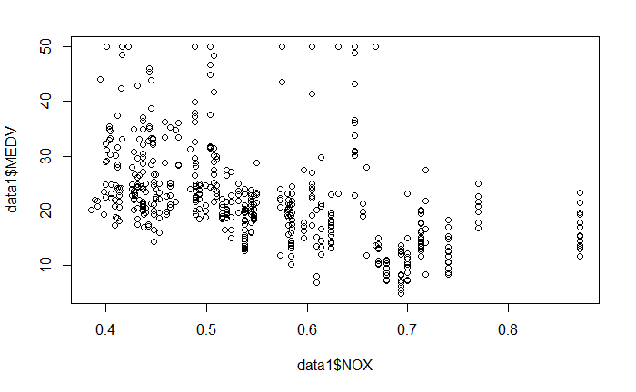

```r
plot(data1$NOX,data1$MEDV)
```

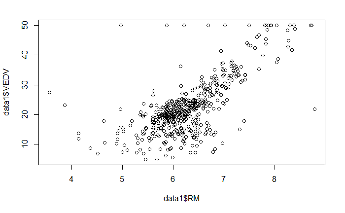

```r
plot(data1$RM,data1$MEDV)
```

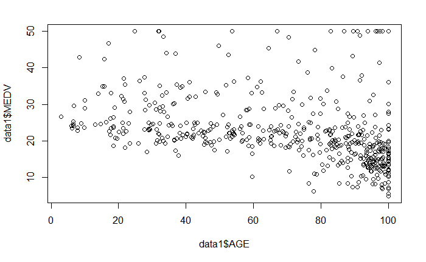

```r
plot(data1$AGE,data1$MEDV)
```

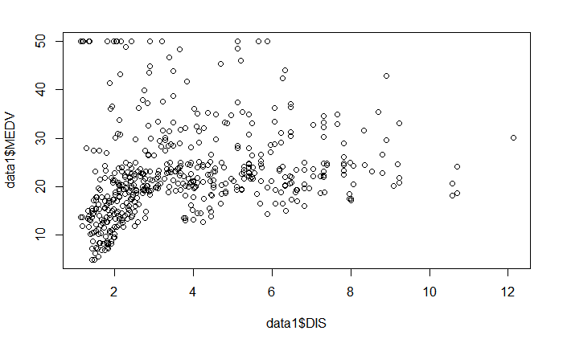

```r
plot(data1$DIS,data1$MEDV)
```

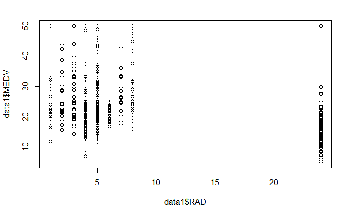

```r
plot(data1$RAD,data1$MEDV)
```

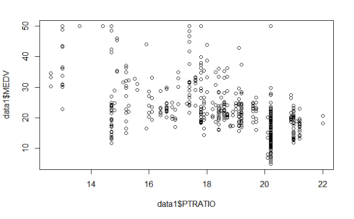

```r
plot(data1$PTRATIO,data1$MEDV)
```

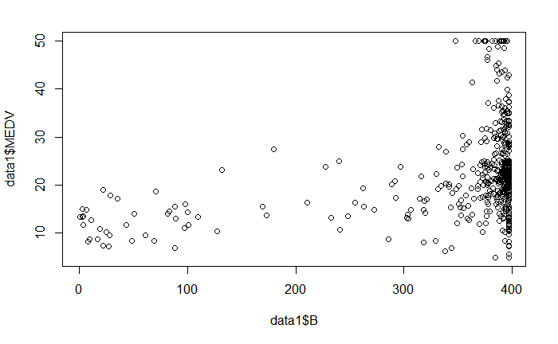

```r
plot(data1$B,data1$MEDV)
```

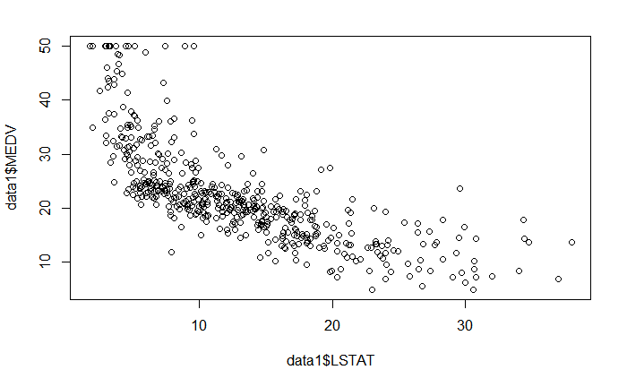

```r
plot(data1$LSTAT,data1$MEDV)
```

LSATAT has curvilinear response

Transforming the LSAT variable.

```r
LSTAT_sq <- 1/data1$LSTAT
data1 <- subset(data1, select=-c(LSTAT))
data1$LSTAT <- LSTAT_sq


model1=lm(formula = MEDV ~ ., data = data1)
summary(model1)
```

```
Call:
lm(formula = MEDV ~ ., data = data1)

Residuals:
     Min       1Q   Median       3Q      Max
-14.1711  -2.4566  -0.3049   1.8076  27.6406

Coefficients:
              Estimate Std. Error t value Pr(>|t|)
(Intercept)  24.046732   4.451785   5.402 1.03e-07 ***
CRIM         -0.161304   0.029715  -5.428 8.94e-08 ***
ZN           -0.001774   0.012393  -0.143 0.886222
INDUS        -0.128431   0.050468  -2.545 0.011239 *
CHAS          2.236892   0.785773   2.847 0.004601 **
NOX         -17.339817   3.487415  -4.972 9.16e-07 ***
RM            3.032016   0.383348   7.909 1.71e-14 ***
AGE           0.004540   0.011833   0.384 0.701394
DIS          -1.172149   0.184154  -6.365 4.47e-10 ***
RAD           0.138162   0.037370   3.697 0.000243 ***
PTRATIO      -0.891371   0.119669  -7.449 4.25e-13 ***
B             0.009860   0.002441   4.039 6.21e-05 ***
LSTAT        59.245699   3.858366  15.355  < 2e-16 ***
---
Signif. codes:  0 ‘***’ 0.001 ‘**’ 0.01 ‘*’ 0.05 ‘.’ 0.1 ‘ ’ 1

Residual standard error: 4.342 on 493 degrees of freedom
Multiple R-squared:  0.7824,    Adjusted R-squared:  0.7771
F-statistic: 147.8 on 12 and 493 DF,  p-value: < 2.2e-16
```

```r
anova(model1)
```

```
Analysis of Variance Table

Response: MEDV
           Df  Sum Sq Mean Sq  F value    Pr(>F)
CRIM        1  6440.8  6440.8 341.6822 < 2.2e-16 ***
ZN          1  3554.3  3554.3 188.5568 < 2.2e-16 ***
INDUS       1  2551.2  2551.2 135.3426 < 2.2e-16 ***
CHAS        1  1529.8  1529.8  81.1581 < 2.2e-16 ***
NOX         1    76.2    76.2   4.0449   0.04485 *
RM          1 10958.5 10958.5 581.3448 < 2.2e-16 ***
AGE         1    89.9    89.9   4.7669   0.02948 *
DIS         1  1728.0  1728.0  91.6696 < 2.2e-16 ***
RAD         1    33.9    33.9   1.7978   0.18060
PTRATIO     1  1401.7  1401.7  74.3607 < 2.2e-16 ***
B           1   614.3   614.3  32.5862 1.971e-08 ***
LSTAT       1  4444.5  4444.5 235.7800 < 2.2e-16 ***
Residuals 493  9293.2    18.9
---
Signif. codes:  0 ‘***’ 0.001 ‘**’ 0.01 ‘*’ 0.05 ‘.’ 0.1 ‘ ’ 1
```

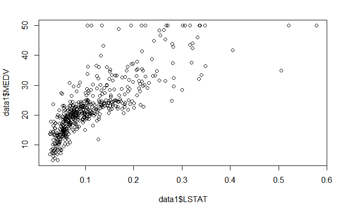

```r
plot(data1$LSTAT,data1$MEDV)
```

### 4.2-4

Analyzing residuals distribution using box plot, we can see there are lot of outliers

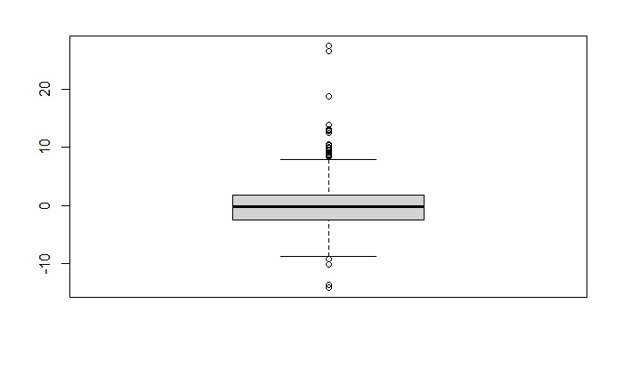

```r
residuals = resid(model1)
boxplot(residuals)
```

### 4.2-5

Plotting residuals vs fitted values graph to check if residuals follow homoscedasticity, here we can see small curvature and outliers towards higher end of fitted values

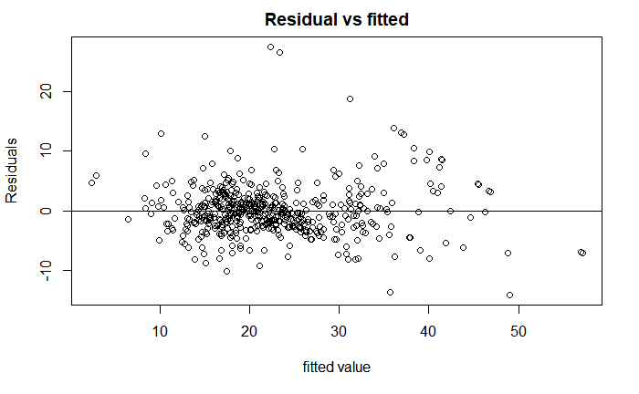

```r
residuals = resid(model1)
plot(fitted(model1), residuals,ylab="Residuals",xlab="fitted value", main="Residual vs fitted")
abline(0,0)
```

### 4.2-6

We can see in the below Normal QQ plot that residuals are deviating from the normal distribution

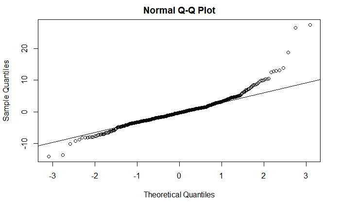

```r
residuals = resid(model1)
qqplot<-(qqnorm(residuals))
qqline(residuals)
```

### 4.2-7

Test whether there is a regression relation; use α = .05 H0 : β1 = β2 = · · · = βp−1 = 0 Ha : not all βi = 0, i = 1, . . . , p − 1

```r
anova(model1)
```

```
Analysis of Variance Table

Response: MEDV
           Df  Sum Sq Mean Sq  F value    Pr(>F)
CRIM        1  6440.8  6440.8 341.6822 < 2.2e-16 ***
ZN          1  3554.3  3554.3 188.5568 < 2.2e-16 ***
INDUS       1  2551.2  2551.2 135.3426 < 2.2e-16 ***
CHAS        1  1529.8  1529.8  81.1581 < 2.2e-16 ***
NOX         1    76.2    76.2   4.0449   0.04485 *
RM          1 10958.5 10958.5 581.3448 < 2.2e-16 ***
AGE         1    89.9    89.9   4.7669   0.02948 *
DIS         1  1728.0  1728.0  91.6696 < 2.2e-16 ***
RAD         1    33.9    33.9   1.7978   0.18060
PTRATIO     1  1401.7  1401.7  74.3607 < 2.2e-16 ***
B           1   614.3   614.3  32.5862 1.971e-08 ***
LSTAT       1  4444.5  4444.5 235.7800 < 2.2e-16 ***
Residuals 493  9293.2    18.9
---
Signif. codes:  0 ‘***’ 0.001 ‘**’ 0.01 ‘*’ 0.05 ‘.’ 0.1 ‘ ’ 1
```

If F∗ ≤ F(1 − α; p − 1, n − p) conclude H0 If F∗ > F(1 − α; p − 1, n − p) conclude Ha

```r
ncol(data1)
```

```
[1] 13
```

```r
f<-qf(0.95,5-1,nrow(data1)-5)
print(f)
```

```
[1] 2.389731
```

Since F*>f we can conclude Ha

### 4.2-8

Breusch Pagan test to check constancy of the error variance

Assuming log σi^2 = γ0 + γ1Xi1 +…..+γnXin; use α = .01

The alternatives are H0 : γ1 = γ2 = 0 Ha : γ1 != 0 or γ2 != 0 or …… γn != 0

```r
library(lmtest)
bptest_val<-bptest(model1, studentize = FALSE)
print(bptest_val)
```

```
    Breusch-Pagan test

data:  model1
BP = 295.68, df = 12, p-value < 2.2e-16
```

Since P value is less than 0.05 we reject Null hypothesis. So there exists non constance in error variance.

### 4.2-9

Now we apply Box Cox transformation on response variable. Box Cox find which transformation on Y will be appropriate to correct skewness of the distributions of error terms,unequal error variances, and non linearity of the regression function. Box cox automatically finds a transformations from family of power transformations on Y such that SSE reduces. ###Box Cox transformation

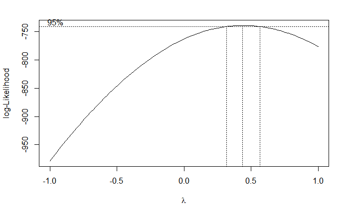

```r
library(MASS)
boccox_values<-boxcox(model1, lambda=seq(-1,1,0.1))
```

```r
print(boccox_values$x[which.max(boccox_values$y)])
```

```
[1] 0.4343434
```

Transformation of Y using lambda=0.4343434 is optimum with minimum SSE.

Now we transform response variable “MEDV” from lambda value obtained from Box Cox method.Replace MEDV column in dataset with new MEDV column with transformation applied on it.

```r
head(data1)
```

|  | CRIM | ZN | INDUS | CHAS | NOX | RM | AGE | DIS | RAD | PTRATIO | B | MEDV | LSTAT |
| --- | --- | --- | --- | --- | --- | --- | --- | --- | --- | --- | --- | --- | --- |
| 1 | 0.00632 | 18 | 2.31 | 0 | 0.538 | 6.575 | 65.2 | 4.0900 | 1 | 15.3 | 396.90 | 24.0 | 0.2008032 |
| 2 | 0.02731 | 0 | 7.07 | 0 | 0.469 | 6.421 | 78.9 | 4.9671 | 2 | 17.8 | 396.90 | 21.6 | 0.1094092 |
| 3 | 0.02729 | 0 | 7.07 | 0 | 0.469 | 7.185 | 61.1 | 4.9671 | 2 | 17.8 | 392.83 | 34.7 | 0.2481390 |
| 4 | 0.03237 | 0 | 2.18 | 0 | 0.458 | 6.998 | 45.8 | 6.0622 | 3 | 18.7 | 394.63 | 33.4 | 0.3401361 |
| 5 | 0.06905 | 0 | 2.18 | 0 | 0.458 | 7.147 | 54.2 | 6.0622 | 3 | 18.7 | 396.90 | 36.2 | 0.1876173 |
| 6 | 0.02985 | 0 | 2.18 | 0 | 0.458 | 6.430 | 58.7 | 6.0622 | 3 | 18.7 | 394.12 | 28.7 | 0.1919386 |

```r
y_transform<-(data1$MEDV)^0.4343434
trans_data1<-subset(data1,select=-c(MEDV))
trans_data1$MEDV<-y_transform
head(trans_data1)
```

|  | CRIM | ZN | INDUS | CHAS | NOX | RM | AGE | DIS | RAD | PTRATIO | B | LSTAT | MEDV |
| --- | --- | --- | --- | --- | --- | --- | --- | --- | --- | --- | --- | --- | --- |
| 1 | 0.00632 | 18 | 2.31 | 0 | 0.538 | 6.575 | 65.2 | 4.0900 | 1 | 15.3 | 396.90 | 0.2008032 | 3.976360 |
| 2 | 0.02731 | 0 | 7.07 | 0 | 0.469 | 6.421 | 78.9 | 4.9671 | 2 | 17.8 | 396.90 | 0.1094092 | 3.798492 |
| 3 | 0.02729 | 0 | 7.07 | 0 | 0.469 | 7.185 | 61.1 | 4.9671 | 2 | 17.8 | 392.83 | 0.2481390 | 4.666937 |
| 4 | 0.03237 | 0 | 2.18 | 0 | 0.458 | 6.998 | 45.8 | 6.0622 | 3 | 18.7 | 394.63 | 0.3401361 | 4.590175 |
| 5 | 0.06905 | 0 | 2.18 | 0 | 0.458 | 7.147 | 54.2 | 6.0622 | 3 | 18.7 | 396.90 | 0.1876173 | 4.753514 |
| 6 | 0.02985 | 0 | 2.18 | 0 | 0.458 | 6.430 | 58.7 | 6.0622 | 3 | 18.7 | 394.12 | 0.1919386 | 4.297554 |

Now we fit the model with transformed variables.

```r
model2=lm(formula = MEDV ~ ., data = trans_data1)
summary(model2)
```

```
Call:
lm(formula = MEDV ~ ., data = trans_data1)

Residuals:
     Min       1Q   Median       3Q      Max
-1.00454 -0.16296 -0.01559  0.14856  1.76635

Coefficients:
              Estimate Std. Error t value Pr(>|t|)
(Intercept)  4.1197397  0.3230326  12.753  < 2e-16 ***
CRIM        -0.0167338  0.0021562  -7.761 4.91e-14 ***
ZN          -0.0007740  0.0008993  -0.861 0.389854
INDUS       -0.0089527  0.0036621  -2.445 0.014848 *
CHAS         0.1644304  0.0570176   2.884 0.004100 **
NOX         -1.3329768  0.2530556  -5.268 2.07e-07 ***
RM           0.2022404  0.0278167   7.270 1.41e-12 ***
AGE         -0.0005344  0.0008586  -0.622 0.533932
DIS         -0.0757576  0.0133627  -5.669 2.44e-08 ***
RAD          0.0093114  0.0027117   3.434 0.000645 ***
PTRATIO     -0.0639371  0.0086835  -7.363 7.59e-13 ***
B            0.0008116  0.0001771   4.582 5.83e-06 ***
LSTAT        3.7803187  0.2799727  13.502  < 2e-16 ***
---
Signif. codes:  0 ‘***’ 0.001 ‘**’ 0.01 ‘*’ 0.05 ‘.’ 0.1 ‘ ’ 1

Residual standard error: 0.315 on 493 degrees of freedom
Multiple R-squared:  0.7797,    Adjusted R-squared:  0.7743
F-statistic: 145.4 on 12 and 493 DF,  p-value: < 2.2e-16
```

```r
anova(model2)
```

```
Analysis of Variance Table

Response: MEDV
           Df Sum Sq Mean Sq  F value    Pr(>F)
CRIM        1 48.710  48.710 490.7670 < 2.2e-16 ***
ZN          1 17.506  17.506 176.3798 < 2.2e-16 ***
INDUS       1 15.030  15.030 151.4288 < 2.2e-16 ***
CHAS        1  6.981   6.981  70.3336 5.299e-16 ***
NOX         1  1.034   1.034  10.4226  0.001328 **
RM          1 46.743  46.743 470.9520 < 2.2e-16 ***
AGE         1  0.876   0.876   8.8243  0.003117 **
DIS         1  7.366   7.366  74.2172 < 2.2e-16 ***
RAD         1  0.227   0.227   2.2896  0.130883
PTRATIO     1  6.959   6.959  70.1115 5.848e-16 ***
B           1  3.640   3.640  36.6729 2.773e-09 ***
LSTAT       1 18.095  18.095 182.3163 < 2.2e-16 ***
Residuals 493 48.931   0.099
---
Signif. codes:  0 ‘***’ 0.001 ‘**’ 0.01 ‘*’ 0.05 ‘.’ 0.1 ‘ ’ 1
```

Fit linear regression model on data set with aforementioned transformation applied. Therefore after applying Box Cox transformation Adjusted R square marginally decreased from 0.7771 to 0.7743.But Residual standard error decreased from 4.342 to 0.315.

Box plot of residuals before and after Box cox transformation. We can see that residuals out liers patterns have been distributed on either side of minimum and maximum values

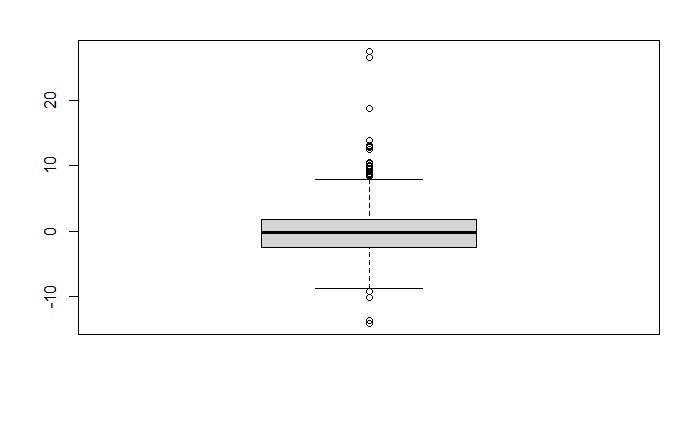

```r
residuals = resid(model1)
boxplot(residuals)
```

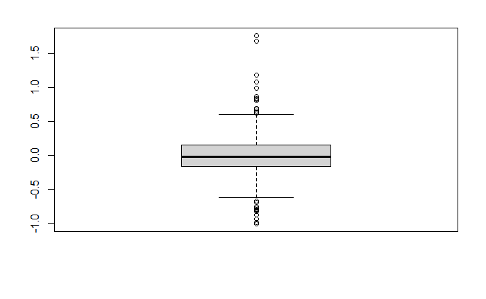

```r
residuals = resid(model2)
boxplot(residuals)
```

We can see the change in distribution of residuals around zero after Box Cox transformation is applied.

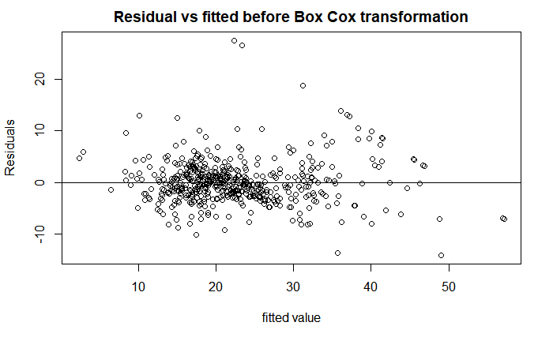

```r
residuals = resid(model1)
plot(fitted(model1), residuals,ylab="Residuals",xlab="fitted value", main="Residual vs fitted before Box Cox transformation")
abline(0,0)
```

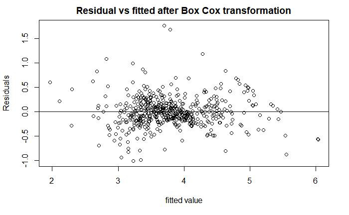

```r
residuals = resid(model2)
plot(fitted(model2), residuals,ylab="Residuals",xlab="fitted value", main="Residual vs fitted after Box Cox transformation")
abline(0,0)
```

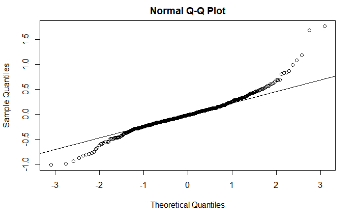

```r
residuals = resid(model2)
qqplot<-(qqnorm(residuals))
qqline(residuals)
```

We observe that still the residuals are not following normal distribution due to outliers, as observed on top and bottom corner of the QQ plot.

### 4.2-10-a

Identifying outlying Y observations based on Studentized deleted residuals

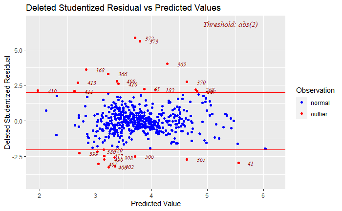

```r
library("olsrr")
del_residuals=ols_plot_resid_stud_fit(model=model2)
```

Analyzing data object returned by “ols_plot_resid_stud_fit” function

```r
print(del_residuals$data)
```

|  | obs | pred | dsr | color | fct_color | txt |
| --- | --- | --- | --- | --- | --- | --- |
| 1 | 1 | 4.465230 | -1.565180e+00 | normal | normal | NA |
| 2 | 2 | 3.927227 | -4.104193e-01 | normal | normal | NA |
| 3 | 3 | 4.612392 | 1.744371e-01 | normal | normal | NA |
| 4 | 4 | 4.859151 | -8.718059e-01 | normal | normal | NA |
| 5 | 5 | 4.309455 | 1.422969e+00 | normal | normal | NA |
| 6 | 6 | 4.176779 | 3.864014e-01 | normal | normal | NA |
| 7 | 7 | 3.798602 | 3.115792e-01 | normal | normal | NA |
| 8 | 8 | 3.679039 | 1.653982e+00 | normal | normal | NA |
| 9 | 9 | 3.477021 | -3.158990e-01 | normal | normal | NA |
| 10 | 10 | 3.616877 | -1.043104e-01 | normal | normal | NA |

[output cut: 496 more lines]

```r
del_residuals<-del_residuals$data[,'dsr']
print(del_residuals)
```

```
  [1] -1.565180e+00 -4.104193e-01  1.744371e-01 -8.718059e-01  1.422969e+00  3.864014e-01
  [7]  3.115792e-01  1.653982e+00 -3.158990e-01 -1.043104e-01 -1.283132e+00 -4.354620e-01
 [13]  2.464791e-01  3.137716e-01 -4.470804e-02  2.411042e-01  5.514261e-01  1.233394e-01
 [19]  1.042302e+00  8.965315e-02 -5.378898e-01  5.901618e-01 -5.072919e-01 -4.329956e-01
 [25] -2.568758e-01 -3.130847e-01  1.315376e-01 -2.895408e-01 -1.352787e-02  4.432562e-01
 [31] -7.463828e-01 -8.349395e-01 -3.730840e-01 -8.335042e-01 -5.893827e-01 -9.935455e-01
 [37] -2.398150e-01 -2.634687e-01  6.957875e-01  2.881408e-04 -2.941402e+00 -6.818561e-01
 [43] -1.468437e-01  1.196978e-01 -1.875349e-01 -5.143143e-01 -7.234920e-02 -6.882464e-01
 [49] -6.304396e-01  2.898019e-01 -1.506846e-01 -3.970684e-01 -6.698831e-01  1.495908e-01
 [55]  7.702916e-01  1.293437e+00  1.939045e-01 -2.735108e-01  5.090731e-01 -8.791355e-03
 [61]  3.785834e-01 -4.409209e-01 -8.197963e-02  1.400518e+00  2.254162e+00 -1.472608e+00
 [67] -7.191430e-01  5.468132e-02 -3.490284e-01 -8.024585e-02 -1.850083e-01  1.360383e-01
 [73] -6.933021e-01 -4.038601e-02 -3.538046e-01 -4.102659e-01 -4.474893e-01 -3.979498e-01
 [79]  7.549404e-02 -4.428331e-01 -9.310476e-02 -2.488894e-01 -3.283113e-02 -1.535250e-01
 [85]  7.762568e-02 -1.246089e-01  2.194458e-01 -5.521827e-01 -1.572231e+00 -4.574902e-01
```

[output cut: 70 more lines]

```r
n<-nrow(data1)
p<-14
t_test<-qt(1-(0.05/(2*nrow(data1))),n-p-1) #t(1-alpha/2*n; n - p - 1)
print(t_test)
```

```
[1] 3.925756
```

```r
outliers_wrt_y<-del_residuals[abs(del_residuals)>t_test]
print(outliers_wrt_y)
```

```
[1] 4.018788 5.832288 5.609406
```

```r
print(outliers_wrt_y)
```

```
[1] 4.018788 5.832288 5.609406
```

### 4.2-10-b

Identifying outlying X observations - HAT matrix Leverage values

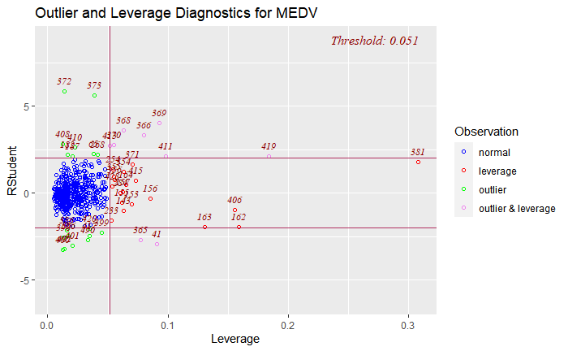

```r
resid_lev<-ols_plot_resid_lev(model2, print_plot = TRUE)
```

Analyzing leverage values of all observations calculated by “ols_plot_resid_lev” library

```r
print(resid_lev$data)
```

|  | obs | leverage | rstudent | color | fct_color | txt |
| --- | --- | --- | --- | --- | --- | --- |
| 1 | 1 | 0.014188605 | -1.565180e+00 | normal | normal | NA |
| 2 | 2 | 0.010383295 | -4.104193e-01 | normal | normal | NA |
| 3 | 3 | 0.016797616 | 1.744371e-01 | normal | normal | NA |
| 4 | 4 | 0.041402112 | -8.718059e-01 | normal | normal | NA |
| 5 | 5 | 0.016776881 | 1.422969e+00 | normal | normal | NA |
| 6 | 6 | 0.017371024 | 3.864014e-01 | normal | normal | NA |
| 7 | 7 | 0.014269269 | 3.115792e-01 | normal | normal | NA |
| 8 | 8 | 0.028245400 | 1.653982e+00 | normal | normal | NA |
| 9 | 9 | 0.034454056 | -3.158990e-01 | normal | normal | NA |
| 10 | 10 | 0.028411045 | -1.043104e-01 | normal | normal | NA |

[output cut: 496 more lines]

```r
leverages<-resid_lev$data[,'leverage']
print(leverages)
```

```
  [1] 0.014188605 0.010383295 0.016797616 0.041402112 0.016776881 0.017371024 0.014269269
  [8] 0.028245400 0.034454056 0.028411045 0.030786611 0.023533491 0.016835442 0.012484800
 [15] 0.013208753 0.012734044 0.022199729 0.011766211 0.023352218 0.011414277 0.017066678
 [22] 0.013111111 0.014155548 0.017154634 0.015427703 0.016206299 0.015323491 0.015693792
 [29] 0.017047373 0.015644356 0.015637386 0.017249428 0.019178734 0.015524289 0.020952188
 [36] 0.007586516 0.009289075 0.010989914 0.015651126 0.030134873 0.090923488 0.026306752
 [43] 0.022431724 0.022461416 0.010122476 0.012254712 0.013053905 0.018287917 0.028458377
 [50] 0.014254940 0.011683214 0.013175181 0.012053116 0.012621676 0.038452713 0.030371475
 [57] 0.029081625 0.038104079 0.014855225 0.009825295 0.016172094 0.026610121 0.016654588
 [64] 0.015531704 0.038015117 0.024995075 0.031262986 0.011981128 0.011323046 0.009654387
 [71] 0.025516145 0.019985467 0.024914979 0.025639918 0.029657785 0.012370100 0.013416892
 [78] 0.012911524 0.013005439 0.014399434 0.007287122 0.009032951 0.007029165 0.005833409
 [85] 0.008241472 0.007728417 0.010479992 0.009642796 0.015362979 0.011408129 0.011337298
 [92] 0.011622340 0.015697568 0.021241571 0.017505500 0.012143228 0.013564224 0.025026343
 [99] 0.025459823 0.015250742 0.013080700 0.012733174 0.043585087 0.012753931 0.014304347
```

[output cut: 58 more lines]

By a rule that any leverage values greater than 2p/n are considered as outlying observations with respect to X values. From this formula we found leverage threshold as 0.05533597

```r
n<-nrow(data1)
p<-14
leverage_thresh<-(2*p)/n
print("leverage_thresh=")
```

```
[1] "leverage_thresh="
```

```r
print(leverage_thresh)
```

```
[1] 0.05533597
```

These are the observations having leverage vales greater than leverage threshold point calculated.

```r
outliers_wrt_x<-leverages[abs(leverages)>leverage_thresh]
print(outliers_wrt_x)
```

```
 [1] 0.09092349 0.06325372 0.06959399 0.06183171 0.08536296 0.06210154 0.15902831 0.13061258
 [9] 0.06534661 0.06055498 0.06339726 0.05599355 0.07758970 0.08014629 0.06342657 0.09302315
[17] 0.05533683 0.07059206 0.30793396 0.15559824 0.09786595 0.07295751 0.18382859
```